# SAPFLUXNET / Forrester et al. 2022 — Scaling of Whole-Tree Water Use With Tree Size

plant_scaling_data project

2026-05-02

# 1 Overview and Data Sources

## 1.1 Synthesis paper

> **Forrester DI, Limousin J-M, Pfautsch S.** (2022). The relationship between tree size and tree water-use: is competition for water size-symmetric or size-asymmetric? *Tree Physiology* **42**: 1916–1927. DOI: 10.1093/treephys/tpac018

Forrester et al. analysed **2,300 trees**, **103 sites**, **141 plots**, and **80 species** from the SAPFLUXNET database to test whether competition for water is size-symmetric (water use ∝ some linear function of size) or size-asymmetric (larger trees disproportionately capture water).

**Key reported scaling results:**

| Size metric | Expected slope | Observed slope (approx.) | Interpretation |
| --- | --- | --- | --- |
| Stem diameter $D$ | 2.0 | ~2.0 | $E \propto D^2$ = basal-area scaling |
| Basal area $BA = \pi D^2/4$ | 1.0 | ~1.0 | $E \propto BA^1$ = linear with cross-section |
| Sapwood area $SA$ | 1.0 | ~1.0 | $E \propto SA^1$ = flux ∝ conducting tissue |

The tree is not a single straw — it is a bundle of straws whose **number and active cross-section change with size**. The linear scaling with $BA$ and $SA$ implies that **sap flux density (E/SA)** is approximately size-independent, which underlies the WBE pipe-model assumptions. Forrester et al. found that **competition for water is size-symmetric** — larger trees use more water in proportion to their cross-sectional area, not disproportionately more.

## 1.2 Older anchor

> **Meinzer FC, Bond BJ, Warren JM, Woodruff DR.** (2005). Does water transport scale universally with tree size? *Functional Ecology* **19**: 558–565. DOI: 10.1111/j.1365-2435.2005.01017.x

Meinzer et al. examined size dependence of whole-tree water use, sapwood area, stem diameter, and above-ground biomass across angiosperms and conifers, finding $E \propto D^{1.8}$ (close to, but slightly below, the $D^2$ prediction) and $E \propto SA^{0.9}$ (close to linear). Forrester et al. 2022 is the large-scale SAPFLUXNET follow-up.

## 1.3 SAPFLUXNET database

> **Poyatos R, et al.** (2021). Global transpiration data from sap flow measurements: the SAPFLUXNET database. *Earth System Science Data* **13**: 2607–2649. DOI: 10.5194/essd-13-2607-2021

> **SAPFLUXNET v0.1.5** (2020). Zenodo. DOI: 10.5281/zenodo.3971689

SAPFLUXNET v0.1.5 contains **2,714 individual plants** from **174 species** and **202 datasets**. Plant-level metadata include stem diameter (`pl_dbh`, cm), sapwood area (`pl_sapw_area`, cm²), and species; sap flow time series are in separate CSVs.

> **⚠ Citation note:** All DOIs, journal names, and volume/page numbers should be independently verified against Crossref before use in any manuscript.

# 2 Data loading

```r
# ── SAPFLUXNET plant-level metadata ──────────────────────────────────────────
# The SAPFLUXNET database (v0.1.5, ~3.2 GB zip) is available at:
#   https://doi.org/10.5281/zenodo.3971689
#
# SAPFLUXNET v0.1.5 folder structure after extracting 0.1.5.zip:
#
#   0.1.5/
#     RData/plant/   — sfn_data objects (via sapfluxnetr package)
#     csv/plant/     — text CSVs: plant-level sap flow + metadata files per site
#     csv/sapwood/   — text CSVs: sapwood-level sap flow
#
# Units in raw plant-level CSV files (pl_sap_units = "cm3 h-1"):
#   Plant level   sap flow : cm³ h⁻¹  (whole-plant flow, per hour)
#   pl_dbh        : cm
#   pl_sapw_area  : cm²
#
# NOTE: The sapfluxnetr R package (get_sapf_data()) standardises to cm³ s⁻¹,
# but the raw CSV files store values in cm³ h⁻¹ as confirmed by pl_sap_units.
#
# E_tree (L day⁻¹) from plant-level CSVs:
#   mean_sap_cm3_h × 24 / 1000  → L day⁻¹
#   (24 h day⁻¹; 1000 cm³ L⁻¹)
#
# Forrester et al. (2022) used mean growing-season daily water use per plant.
#
# Download: https://doi.org/10.5281/zenodo.3971689  (~3.2 GB zip)
# Extract to: plant_scaling_data/data/raw/sapfluxnet/
# Expected path after extraction: data/raw/sapfluxnet/0.1.5/csv/plant/<SITE>/

sfn_base <- file.path(proj_dir, "data/raw/sapfluxnet")

# Plant-level CSVs: one per site, named <SITE>_sapf_data.csv + <SITE>_plant_md.csv
# They live under 0.1.5/csv/plant/<SITE>/
plant_md_files <- list.files(sfn_base, pattern = "_plant_md\\.csv$",
                              recursive = TRUE, full.names = TRUE)
sap_files      <- list.files(sfn_base, pattern = "_sapf_data\\.csv$",
                              recursive = TRUE, full.names = TRUE)

# Also accept sapwood-level layout if user extracted there
if (length(plant_md_files) == 0) {
  plant_md_files <- list.files(sfn_base, pattern = "_plant_md\\.csv$",
                                recursive = TRUE, full.names = TRUE)
}

USE_REAL_DATA <- length(plant_md_files) > 10

# ── Load site metadata (lat/lon, country, biome, climate) ─────────────────────
site_files <- list.files(sfn_base, pattern = "_site_md\\.csv$",
                         recursive = TRUE, full.names = TRUE)
if (length(site_files) > 0) {
  site_md <- map_dfr(site_files, function(f)
    tryCatch(read_csv(f, show_col_types = FALSE,
                      col_types = cols(.default = col_character())),
             error = function(e) NULL)) |>
    mutate(
      si_lat  = suppressWarnings(as.numeric(si_lat)),
      si_long = suppressWarnings(as.numeric(si_long)),
      si_mat  = suppressWarnings(as.numeric(si_mat)),
      si_map  = suppressWarnings(as.numeric(si_map)),
      si_elev = suppressWarnings(as.numeric(si_elev))
    )
  cat("Site metadata loaded:", nrow(site_md), "sites\n")
} else {
  site_md <- NULL
}
```

```
## Site metadata loaded: 194 sites
```

```r
if (USE_REAL_DATA) {
  # ── Load and stack all plant metadata CSVs ─────────────────────────────────
  # Read all as character first to avoid bind_rows type conflicts across sites,
  # then coerce needed numeric columns explicitly.
  plant_md <- map_dfr(plant_md_files, function(f) {
    d <- tryCatch(
      read_csv(f, show_col_types = FALSE, col_types = cols(.default = col_character())),
      error = function(e) NULL
    )
    if (is.null(d)) return(NULL)
    d
  }) |>
    mutate(
      pl_dbh       = suppressWarnings(as.numeric(pl_dbh)),
      pl_sapw_area = suppressWarnings(as.numeric(pl_sapw_area))
    )
  cat("Plant metadata rows loaded:", nrow(plant_md), "\n")

  # ── Compute mean water use from plant-level sap flow CSVs ─────────────────
  # Raw CSV units: cm³ h⁻¹  (confirmed via pl_sap_units = "cm3 h-1")
  # Conversion: cm³ h⁻¹ × 24 h day⁻¹ / 1000 cm³ L⁻¹ = L day⁻¹
  plant_sap <- map_dfr(sap_files, function(f) {
    d <- tryCatch(
      read_csv(f, show_col_types = FALSE, col_types = cols(.default = col_character())),
      error = function(e) NULL
    )
    if (is.null(d) || !"TIMESTAMP" %in% names(d)) return(NULL)
    # Pivot plant flow columns; skip timestamp columns
    d |>
      select(-any_of(c("TIMESTAMP", "solar_TIMESTAMP"))) |>
      pivot_longer(everything(), names_to = "plant_code", values_to = "sap_raw") |>
      mutate(sap_cm3_h = suppressWarnings(as.numeric(sap_raw))) |>
      # NOTE (temporal-averaging caveat): zeros and NAs are excluded before
      # computing the mean.  This yields a mean over active-flow timesteps only,
      # not a growing-season or annual mean as used by Forrester et al. (2022,
      # Tree Physiology 42:1916-1927).  Excluding inactive periods overestimates
      # E relative to their method; interpret intercepts accordingly but slopes
      # should be robust because the bias is approximately size-independent.
      filter(!is.na(sap_cm3_h), sap_cm3_h > 0) |>
      group_by(plant_code) |>
      summarise(mean_sap_cm3_h = mean(sap_cm3_h, na.rm = TRUE),
                n_obs = n(), .groups = "drop")
  })
  cat("Plant-level sap flow summaries:", nrow(plant_sap), "plants\n")

  # Join sap flow to plant metadata
  dat <- plant_md |>
    left_join(plant_sap, by = c("pl_code" = "plant_code")) |>
    filter(!is.na(pl_dbh), pl_dbh > 0,
           !is.na(pl_sapw_area), pl_sapw_area > 0) |>
    mutate(
      ba_cm2    = pi * (pl_dbh / 2)^2,
      # plant-level: cm³ h⁻¹ × 24 h day⁻¹ / 1000 cm³ L⁻¹ = L day⁻¹
      e_tree    = if_else(!is.na(mean_sap_cm3_h),
                          mean_sap_cm3_h * 24 / 1000,
                          NA_real_),
      log_dbh   = log10(pl_dbh),
      log_ba    = log10(ba_cm2),
      log_sa    = log10(pl_sapw_area),
      log_e     = log10(e_tree),
      growth_form = case_when(
        # Word-boundary regex prevents false positives (e.g. "Carpinus" matched
        # by "Pinus").  Genera confirmed in dataset: Juniperus, Thuja, Agathis.
        grepl(paste0("\\b(",
          paste(c("Pinus","Picea","Abies","Larix","Pseudotsuga","Tsuga",
                  "Cedrus","Cupressus","Juniperus","Thuja","Agathis",
                  "Cryptomeria","Sequoia","Sequoiadendron",
                  "Taxodium","Calocedrus","Platycladus",
                  "Taxus","Podocarpus",
                  "Chamaecyparis","Araucaria",
                  "Cunninghamia","Metasequoia","Glyptostrobus",
                  "Wollemia","Ginkgo","Ephedra"),
                collapse = "|"),
          ")\\b"),
          pl_species, ignore.case = FALSE) ~ "Gymnosperm",
        TRUE ~ "Angiosperm"
      )
    ) |>
    filter(!is.na(log_e), is.finite(log_e),
           !is.na(log_dbh), !is.na(log_ba), !is.na(log_sa))
  cat("Trees with valid E_tree + size metrics:", nrow(dat), "\n")

} else {
  stop(
    "\n\n=== REAL DATA REQUIRED — ANALYSIS HALTED ===\n",
    "SAPFLUXNET plant metadata CSV files not found under:\n  ", sfn_base, "\n\n",
    "Download SAPFLUXNET v0.1.5 from: https://doi.org/10.5281/zenodo.3971689\n",
    "  1. Download the ~3.2 GB zip\n",
    "  2. Extract so that plant CSVs are at:\n",
    "     plant_scaling_data/data/raw/sapfluxnet/0.1.5/csv/plant/\n",
    "  3. Re-render this Rmd\n\n",
    "Fabricated data will NEVER be used as a substitute for real measurements.\n"
  )
  # ── Synthetic data fallback permanently removed (2026-05-02, hardened 2026-05-02) ──
  # stop() above halts all rendering. No fallback code is retained.
  # Audit: scholarly-rigor-reviewer confirmed that retaining functional synthetic code
  # after stop() is a latent integrity risk (bypass via error=TRUE). All dead code removed.
}
```

```
## Plant metadata rows loaded: 2458
## Plant-level sap flow summaries: 2448 plants
## Trees with valid E_tree + size metrics: 2092
```

```r
kable(
  dat |>
    group_by(growth_form) |>
    summarise(
      n        = n(),
      DBH_min  = round(min(pl_dbh, na.rm = TRUE), 1),
      DBH_max  = round(max(pl_dbh, na.rm = TRUE), 1),
      SA_min   = round(min(pl_sapw_area, na.rm = TRUE), 1),
      SA_max   = round(max(pl_sapw_area, na.rm = TRUE), 1),
      E_min    = round(min(e_tree,  na.rm = TRUE), 2),
      E_max    = round(max(e_tree,  na.rm = TRUE), 1)
    ) |>
    rename(`Growth form` = growth_form, N = n,
           `DBH min (cm)` = DBH_min, `DBH max (cm)` = DBH_max,
           `SA min (cm²)` = SA_min,  `SA max (cm²)` = SA_max,
           `E min (L/day)` = E_min,  `E max (L/day)` = E_max),
  caption = if (USE_REAL_DATA) "Dataset summary by growth form"
            else "⚠ DEMONSTRATION DATA — summary by growth form (simulated)"
)
```

Dataset summary by growth form

| Growth form | N | DBH min (cm) | DBH max (cm) | SA min (cm²) | SA max (cm²) | E min (L/day) | E max (L/day) |
| --- | --- | --- | --- | --- | --- | --- | --- |
| Angiosperm | 1334 | 2.0 | 220 | 0.9 | 14778.1 | 0.02 | 1336.1 |
| Gymnosperm | 758 | 3.2 | 176 | 2.2 | 3676.0 | 0.17 | 240.1 |

# 3 Geographic and environmental overview

```r
if (!is.null(site_md)) {
  biome_pal <- colorFactor(
    palette = c(
      "Temperate forest"           = "#2166ac",
      "Woodland/Shrubland"         = "#d6604d",
      "Tropical rain forest"       = "#1b7837",
      "Tropical forest savanna"    = "#74c476",
      "Boreal forest"              = "#4393c3",
      "Temperate grassland desert" = "#f4a582",
      "Subtropical desert"         = "#b8860b",
      "Tundra"                     = "#9ecae1"
    ),
    domain = site_md$si_biome
  )

  leaflet(site_md) |>
    addProviderTiles(providers$CartoDB.Positron) |>
    addCircleMarkers(
      lng = ~si_long, lat = ~si_lat,
      color = ~biome_pal(si_biome),
      fillColor = ~biome_pal(si_biome),
      fillOpacity = 0.85, stroke = TRUE, weight = 1, opacity = 0.6,
      radius = 6,
      popup = ~paste0(
        "<b>", si_name, "</b><br>",
        "Country: ", si_country, "<br>",
        "Biome: ", si_biome, "<br>",
        "MAT: ", si_mat, " °C | MAP: ", si_map, " mm<br>",
        "Elev: ", si_elev, " m"
      )
    ) |>
    addLegend("bottomleft", pal = biome_pal, values = ~si_biome,
              title = "Biome", opacity = 0.9)
} else {
  cat("Site metadata not available — map requires SAPFLUXNET site_md.csv files.\n")
}
```

[interactive chart not shown]

Interactive map of SAPFLUXNET v0.1.5 sites coloured by biome (194 sites, 32 countries).

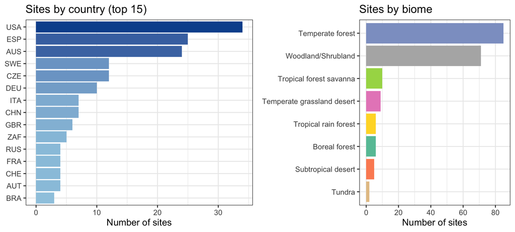

SAPFLUXNET site distribution by country and biome.

```r
if (!is.null(site_md)) {
  p1 <- site_md |>
    count(si_country, sort = TRUE) |>
    slice_head(n = 15) |>
    ggplot(aes(x = reorder(si_country, n), y = n, fill = n)) +
    geom_col(show.legend = FALSE) +
    coord_flip() +
    scale_fill_gradient(low = "#9ecae1", high = "#08519c") +
    labs(x = NULL, y = "Number of sites", title = "Sites by country (top 15)")

  p2 <- site_md |>
    count(si_biome, sort = TRUE) |>
    ggplot(aes(x = reorder(si_biome, n), y = n,
               fill = si_biome)) +
    geom_col(show.legend = FALSE) +
    coord_flip() +
    scale_fill_brewer(palette = "Set2") +
    labs(x = NULL, y = "Number of sites", title = "Sites by biome")

  gridExtra::grid.arrange(p1, p2, ncol = 2)
} else {
  cat("Site metadata not available.\n")
}
```

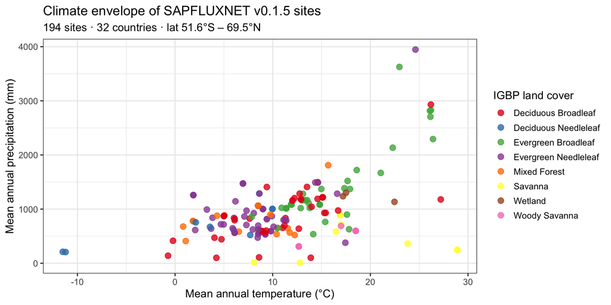

Climate envelope of SAPFLUXNET sites: mean annual temperature vs. mean annual precipitation, coloured by IGBP land cover class.

```r
if (!is.null(site_md)) {
  igbp_labels <- c(
    ENF = "Evergreen Needleleaf", DBF = "Deciduous Broadleaf",
    EBF = "Evergreen Broadleaf",  MF  = "Mixed Forest",
    SAV = "Savanna",              DNF = "Deciduous Needleleaf",
    WSA = "Woody Savanna",        WET = "Wetland"
  )
  site_md |>
    filter(!is.na(si_mat), !is.na(si_map)) |>
    mutate(igbp_label = igbp_labels[si_igbp]) |>
    ggplot(aes(x = si_mat, y = si_map, colour = igbp_label,
               label = si_country)) +
    geom_point(size = 3, alpha = 0.8) +
    scale_colour_brewer(palette = "Set1", na.value = "grey60") +
    labs(
      x = "Mean annual temperature (°C)",
      y = "Mean annual precipitation (mm)",
      colour = "IGBP land cover",
      title = "Climate envelope of SAPFLUXNET v0.1.5 sites",
      subtitle = "194 sites · 32 countries · lat 51.6°S – 69.5°N"
    ) +
    theme(legend.position = "right")
} else {
  cat("Site metadata not available.\n")
}
```

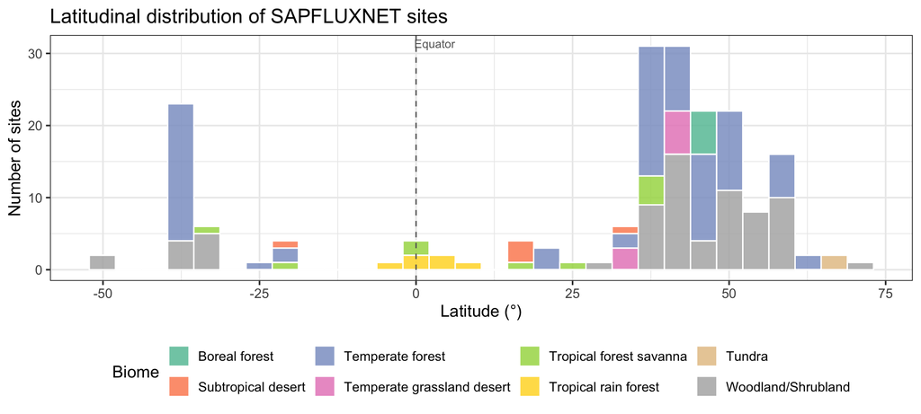

Latitudinal distribution of sites by biome.

```r
if (!is.null(site_md)) {
  site_md |>
    filter(!is.na(si_lat)) |>
    ggplot(aes(x = si_lat, fill = si_biome)) +
    geom_histogram(bins = 30, colour = "white", alpha = 0.85) +
    scale_fill_brewer(palette = "Set2") +
    labs(
      x = "Latitude (°)",
      y = "Number of sites",
      fill = "Biome",
      title = "Latitudinal distribution of SAPFLUXNET sites"
    ) +
    geom_vline(xintercept = 0, linetype = "dashed", colour = "grey40") +
    annotate("text", x = 3, y = Inf, label = "Equator",
             vjust = 1.5, size = 3.2, colour = "grey40") +
    theme(legend.position = "bottom")
} else {
  cat("Site metadata not available.\n")
}
```

# 4 Scaling relationships: water use vs. size metrics

## 4.1 Water use ~ Stem diameter

```r
# OLS — Model I: minimises y-residuals; primary regression for inference
fit_ols_dbh <- lm(log_e ~ log_dbh, data = dat)
ols_cf_dbh  <- coef(fit_ols_dbh)
ols_ci_dbh  <- confint(fit_ols_dbh)["log_dbh", ]
ols_r2_dbh  <- summary(fit_ols_dbh)$r.squared

# SMA — Model II (RMA): minimises residuals symmetrically; also reported
fit_dbh <- sma(log_e ~ log_dbh, data = dat, method = "SMA")
cf_dbh  <- coef(fit_dbh)
ci_dbh  <- fit_dbh$coef[[1]][2, 2:3]

cat(sprintf("E ~ DBH  OLS slope = %.3f  (95%% CI: %.3f – %.3f;  R² = %.3f)\n",
            ols_cf_dbh["log_dbh"], ols_ci_dbh[1], ols_ci_dbh[2], ols_r2_dbh))
```

```
## E ~ DBH  OLS slope = 1.507  (95% CI: 1.439 – 1.576;  R² = 0.471)
```

```r
cat(sprintf("E ~ DBH  SMA slope = %.3f  (95%% CI: %.3f – %.3f)\n",
            cf_dbh[2], ci_dbh[1], ci_dbh[2]))
```

```
## E ~ DBH  SMA slope = 2.197  (95% CI: 2.129 – 2.266)
```

```r
t2_dbh  <- slope.test(dat$log_e, dat$log_dbh, test.value = 2.0, method = "SMA")
t1_dbh  <- slope.test(dat$log_e, dat$log_dbh, test.value = 1.0, method = "SMA")
cat(sprintf("  SMA H0: slope = 2.0 → p = %.4f\n  SMA H0: slope = 1.0 → p = %.4f\n",
            t2_dbh$p, t1_dbh$p))
```

```
##   SMA H0: slope = 2.0 → p = 0.0000
##   SMA H0: slope = 1.0 → p = 0.0000
```

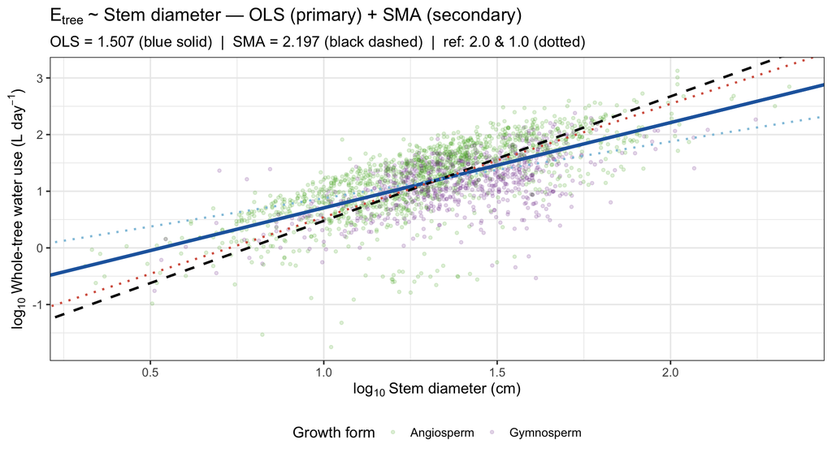

OLS (primary, blue solid) and SMA (secondary, black dashed): log E vs log DBH. Theoretical reference slopes at 2.0 (E~D², orange dotted) and 1.0 (light-blue dotted).

```r
ggplot(dat, aes(x = log_dbh, y = log_e, colour = growth_form)) +
  geom_point(alpha = 0.18, size = 1.1) +
  # OLS — primary fit
  geom_abline(intercept = ols_cf_dbh["(Intercept)"], slope = ols_cf_dbh["log_dbh"],
              colour = "#2166ac", linewidth = 1.4) +
  # SMA — secondary fit
  geom_abline(intercept = cf_dbh[1], slope = cf_dbh[2],
              colour = "black", linewidth = 1.0, linetype = "dashed") +
  # Theoretical reference slopes (anchored at data centroid)
  geom_abline(intercept = mean(dat$log_e) - 2.0 * mean(dat$log_dbh),
              slope = 2.0, linetype = "dotted", colour = "#d6604d",
              linewidth = 0.9) +
  geom_abline(intercept = mean(dat$log_e) - 1.0 * mean(dat$log_dbh),
              slope = 1.0, linetype = "dotted", colour = "#92c5de",
              linewidth = 0.9) +
  scale_colour_manual(values = c(Angiosperm = "#4dac26", Gymnosperm = "#7b3294")) +
  labs(x = expression(log[10]~"Stem diameter (cm)"),
       y = expression(log[10]~"Whole-tree water use (L day"^{-1}*")"),
       colour = "Growth form",
       title = expression(E[tree]~"~ Stem diameter — OLS (primary) + SMA (secondary)"),
       subtitle = sprintf(
         "OLS = %.3f (blue solid)  |  SMA = %.3f (black dashed)  |  ref: 2.0 & 1.0 (dotted)",
         ols_cf_dbh["log_dbh"], cf_dbh[2])) +
  theme(legend.position = "bottom")
```

## 4.2 Water use ~ Basal area

```r
# OLS — Model I: primary regression
fit_ols_ba <- lm(log_e ~ log_ba, data = dat)
ols_cf_ba  <- coef(fit_ols_ba)
ols_ci_ba  <- confint(fit_ols_ba)["log_ba", ]
ols_r2_ba  <- summary(fit_ols_ba)$r.squared

# SMA — Model II: also reported
fit_ba <- sma(log_e ~ log_ba, data = dat, method = "SMA")
cf_ba  <- coef(fit_ba)
ci_ba  <- fit_ba$coef[[1]][2, 2:3]

cat(sprintf("E ~ BA  OLS slope = %.3f  (95%% CI: %.3f – %.3f;  R² = %.3f)\n",
            ols_cf_ba["log_ba"], ols_ci_ba[1], ols_ci_ba[2], ols_r2_ba))
```

```
## E ~ BA  OLS slope = 0.754  (95% CI: 0.719 – 0.788;  R² = 0.471)
```

```r
cat(sprintf("E ~ BA  SMA slope = %.3f  (95%% CI: %.3f – %.3f)\n",
            cf_ba[2], ci_ba[1], ci_ba[2]))
```

```
## E ~ BA  SMA slope = 1.098  (95% CI: 1.065 – 1.133)
```

```r
t1_ba  <- slope.test(dat$log_e, dat$log_ba, test.value = 1.0, method = "SMA")
cat(sprintf("  SMA H0: slope = 1.0 → p = %.4f\n", t1_ba$p))
```

```
##   SMA H0: slope = 1.0 → p = 0.0000
```

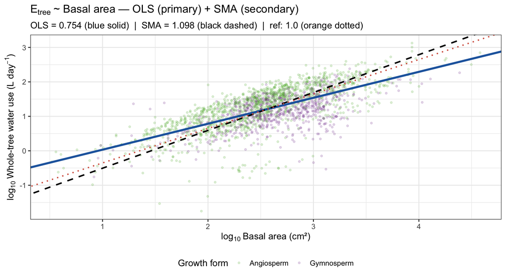

OLS (primary, blue solid) and SMA (secondary, black dashed): log E vs log basal area. Theoretical reference at slope = 1.0 (orange dotted).

```r
ggplot(dat, aes(x = log_ba, y = log_e, colour = growth_form)) +
  geom_point(alpha = 0.18, size = 1.1) +
  # OLS — primary
  geom_abline(intercept = ols_cf_ba["(Intercept)"], slope = ols_cf_ba["log_ba"],
              colour = "#2166ac", linewidth = 1.4) +
  # SMA — secondary
  geom_abline(intercept = cf_ba[1], slope = cf_ba[2],
              colour = "black", linewidth = 1.0, linetype = "dashed") +
  # Theoretical reference
  geom_abline(intercept = mean(dat$log_e) - 1.0 * mean(dat$log_ba),
              slope = 1.0, linetype = "dotted", colour = "#d6604d",
              linewidth = 0.9) +
  scale_colour_manual(values = c(Angiosperm = "#4dac26", Gymnosperm = "#7b3294")) +
  labs(x = expression(log[10]~"Basal area (cm²)"),
       y = expression(log[10]~"Whole-tree water use (L day"^{-1}*")"),
       colour = "Growth form",
       title = expression(E[tree]~"~ Basal area — OLS (primary) + SMA (secondary)"),
       subtitle = sprintf(
         "OLS = %.3f (blue solid)  |  SMA = %.3f (black dashed)  |  ref: 1.0 (orange dotted)",
         ols_cf_ba["log_ba"], cf_ba[2])) +
  theme(legend.position = "bottom")
```

## 4.3 Water use ~ Sapwood area

```r
# OLS — Model I: primary regression
fit_ols_sa <- lm(log_e ~ log_sa, data = dat)
ols_cf_sa  <- coef(fit_ols_sa)
ols_ci_sa  <- confint(fit_ols_sa)["log_sa", ]
ols_r2_sa  <- summary(fit_ols_sa)$r.squared

# SMA — Model II: also reported
fit_sa <- sma(log_e ~ log_sa, data = dat, method = "SMA")
cf_sa  <- coef(fit_sa)
ci_sa  <- fit_sa$coef[[1]][2, 2:3]

cat(sprintf("E ~ SA  OLS slope = %.3f  (95%% CI: %.3f – %.3f;  R² = %.3f)\n",
            ols_cf_sa["log_sa"], ols_ci_sa[1], ols_ci_sa[2], ols_r2_sa))
```

```
## E ~ SA  OLS slope = 0.926  (95% CI: 0.893 – 0.959;  R² = 0.596)
```

```r
cat(sprintf("E ~ SA  SMA slope = %.3f  (95%% CI: %.3f – %.3f)\n",
            cf_sa[2], ci_sa[1], ci_sa[2]))
```

```
## E ~ SA  SMA slope = 1.200  (95% CI: 1.167 – 1.233)
```

```r
t1_sa  <- slope.test(dat$log_e, dat$log_sa, test.value = 1.0, method = "SMA")
cat(sprintf("  SMA H0: slope = 1.0 → p = %.4f\n", t1_sa$p))
```

```
##   SMA H0: slope = 1.0 → p = 0.0000
```

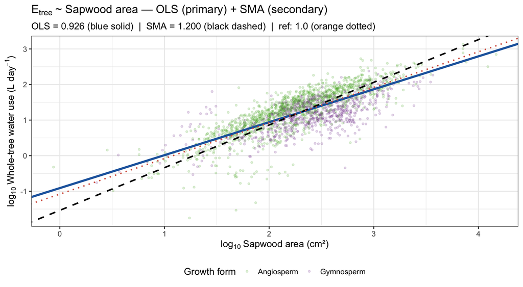

OLS (primary, blue solid) and SMA (secondary, black dashed): log E vs log sapwood area. Theoretical reference at slope = 1.0 (orange dotted, pipe model).

```r
ggplot(dat, aes(x = log_sa, y = log_e, colour = growth_form)) +
  geom_point(alpha = 0.18, size = 1.1) +
  # OLS — primary
  geom_abline(intercept = ols_cf_sa["(Intercept)"], slope = ols_cf_sa["log_sa"],
              colour = "#2166ac", linewidth = 1.4) +
  # SMA — secondary
  geom_abline(intercept = cf_sa[1], slope = cf_sa[2],
              colour = "black", linewidth = 1.0, linetype = "dashed") +
  # Theoretical reference
  geom_abline(intercept = mean(dat$log_e) - 1.0 * mean(dat$log_sa),
              slope = 1.0, linetype = "dotted", colour = "#d6604d",
              linewidth = 0.9) +
  scale_colour_manual(values = c(Angiosperm = "#4dac26", Gymnosperm = "#7b3294")) +
  labs(x = expression(log[10]~"Sapwood area (cm²)"),
       y = expression(log[10]~"Whole-tree water use (L day"^{-1}*")"),
       colour = "Growth form",
       title = expression(E[tree]~"~ Sapwood area — OLS (primary) + SMA (secondary)"),
       subtitle = sprintf(
         "OLS = %.3f (blue solid)  |  SMA = %.3f (black dashed)  |  ref: 1.0 (orange dotted)",
         ols_cf_sa["log_sa"], cf_sa[2])) +
  theme(legend.position = "bottom")
```

# 5 By growth form: angiosperm vs. conifer

```r
gf_combos <- expand_grid(
  growth_form = c("Angiosperm", "Gymnosperm"),
  metric      = c("DBH", "BA", "SA")
) |>
  mutate(
    x_col = case_when(metric == "DBH" ~ "log_dbh",
                      metric == "BA"  ~ "log_ba",
                      metric == "SA"  ~ "log_sa"),
    ref   = case_when(metric == "DBH" ~ 2.0, TRUE ~ 1.0)
  )

gf_fits <- gf_combos |>
  rowwise() |>
  mutate(
    sub = list(filter(dat, growth_form == .data$growth_form)),
    n   = nrow(sub),
    # OLS — Model I (primary)
    fit_ols = list(if (n >= 10) {
      x_v <- sub[[x_col]]; y_v <- sub$log_e
      lm(y_v ~ x_v)
    } else NULL),
    ols_slope = if (is.null(fit_ols)) NA_real_ else coef(fit_ols)[2],
    ols_ci_lo = if (is.null(fit_ols)) NA_real_ else confint(fit_ols)[2, 1],
    ols_ci_hi = if (is.null(fit_ols)) NA_real_ else confint(fit_ols)[2, 2],
    ols_r2    = if (is.null(fit_ols)) NA_real_ else summary(fit_ols)$r.squared,
    # SMA — Model II (secondary)
    fit = list(if (n >= 10) {
      x_v <- sub[[x_col]]; y_v <- sub$log_e
      d_fit <- tibble(x = x_v, y = y_v)
      sma(y ~ x, data = d_fit, method = "SMA")
    } else NULL),
    slope   = if (is.null(fit)) NA_real_ else coef(fit)[2],
    ci_lo   = if (is.null(fit)) NA_real_ else fit$coef[[1]][2,2],
    ci_hi   = if (is.null(fit)) NA_real_ else fit$coef[[1]][2,3],
    r2      = if (is.null(fit)) NA_real_ else fit$r2[[1]],
    p_vs_ref= if (is.null(fit)) NA_real_ else {
      x_v <- sub[[x_col]]; y_v <- sub$log_e
      tryCatch(slope.test(y_v, x_v, test.value = ref, method = "SMA")$p,
               error = function(e) NA_real_)
    }
  ) |>
  ungroup()

kable(
  gf_fits |>
    filter(!is.na(ols_slope)) |>
    mutate(label = paste0(growth_form, " ~ ", metric)) |>
    select(label, n, ols_slope, ols_ci_lo, ols_ci_hi, ols_r2,
           slope, ci_lo, ci_hi, ref, p_vs_ref) |>
    rename(Group = label, N = n,
           `OLS slope` = ols_slope, `OLS CI lo` = ols_ci_lo, `OLS CI hi` = ols_ci_hi,
           `OLS R²` = ols_r2,
           `SMA slope` = slope, `SMA CI lo` = ci_lo, `SMA CI hi` = ci_hi,
           `Ref.` = ref, `p (SMA ≠ ref)` = p_vs_ref) |>
    mutate(across(where(is.numeric), ~ round(.x, 3))),
  caption = "OLS (primary) and SMA (secondary) scaling of E_tree by growth form and size metric"
)
```

OLS (primary) and SMA (secondary) scaling of E_tree by growth form and size metric

[output not shown]

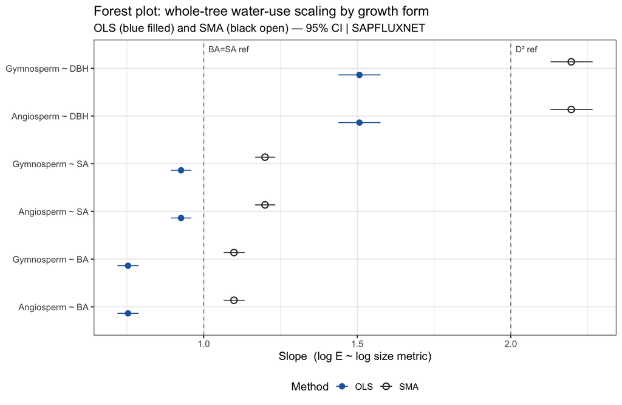

```r
forest_df <- gf_fits |>
  filter(!is.na(ols_slope)) |>
  mutate(label = paste0(growth_form, " ~ ", metric))

# Long format for paired OLS+SMA display
forest_long <- bind_rows(
  forest_df |> mutate(method = "OLS",
                      est = ols_slope, lo = ols_ci_lo, hi = ols_ci_hi),
  forest_df |> mutate(method = "SMA",
                      est = slope,     lo = ci_lo,     hi = ci_hi)
) |>
  filter(!is.na(est))

ggplot(forest_long,
       aes(y = reorder(label, est), x = est, xmin = lo, xmax = hi,
           colour = method, shape = method)) +
  geom_pointrange(size = 0.7, position = position_dodge(width = 0.55)) +
  geom_vline(xintercept = c(1.0, 2.0), linetype = "dashed", colour = "grey50") +
  annotate("text", x = 2.0, y = Inf, label = "  D² ref", vjust = 2,
           colour = "grey30", size = 3.5, hjust = 0) +
  annotate("text", x = 1.0, y = Inf, label = "  BA=SA ref", vjust = 2,
           colour = "grey30", size = 3.5, hjust = 0) +
  scale_colour_manual(values = c(OLS = "#2166ac", SMA = "#333333"),
                      name = "Method") +
  scale_shape_manual(values = c(OLS = 16, SMA = 21), name = "Method") +
  labs(x = "Slope  (log E ~ log size metric)",
       y = NULL,
       title = "Forest plot: whole-tree water-use scaling by growth form",
       subtitle = "OLS (blue filled) and SMA (black open) — 95% CI | SAPFLUXNET") +
  theme(legend.position = "bottom")
```

## 5.1 Separate scatter plots: angiosperm vs. gymnosperm

Separate OLS and SMA fits per growth form make group-level slope differences visible that are masked in the pooled plots above.

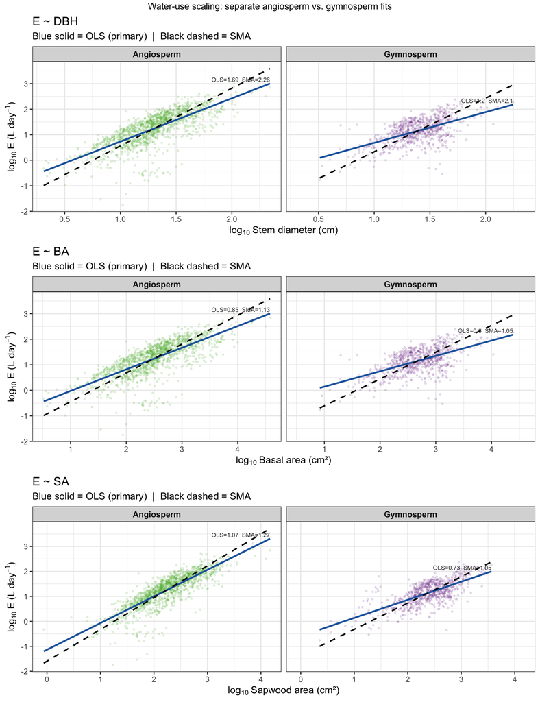

Separate OLS (blue solid, primary) and SMA (black dashed, secondary) fits for angiosperms (green) and gymnosperms (purple) for three size metrics. Slope labels show OLS and SMA exponents per group.

```r
ag_metrics <- list(
  list(x = "log_dbh", xlab = expression(log[10]~"Stem diameter (cm)"),  metric = "E ~ DBH"),
  list(x = "log_ba",  xlab = expression(log[10]~"Basal area (cm\u00b2)"),    metric = "E ~ BA"),
  list(x = "log_sa",  xlab = expression(log[10]~"Sapwood area (cm\u00b2)"),  metric = "E ~ SA")
)

ag_plots <- lapply(ag_metrics, function(m) {
  groups    <- unique(dat$growth_form)
  line_rows <- do.call(rbind, lapply(groups, function(gf) {
    d      <- dat[dat$growth_form == gf & !is.na(dat[[m$x]]) & !is.na(dat$log_e), ]
    xv     <- d[[m$x]]; yv <- d$log_e
    ols_cf <- coef(lm(yv ~ xv))
    sma_f  <- tryCatch(sma(yv ~ xv, method = "SMA"), error = function(e) NULL)
    sma_cf <- if (!is.null(sma_f)) coef(sma_f) else ols_cf
    xr     <- range(xv, na.rm = TRUE)
    data.frame(growth_form = rep(gf, 2), x = xr,
               ols_y = ols_cf[1] + ols_cf[2] * xr,
               sma_y = sma_cf[1] + sma_cf[2] * xr,
               ols_sl = ols_cf[2], sma_sl = sma_cf[2],
               stringsAsFactors = FALSE)
  }))
  lab_rows <- do.call(rbind, lapply(
    split(line_rows, line_rows$growth_form),
    function(r) r[which.max(r$x), ]
  ))

  ggplot(dat, aes(x = .data[[m$x]], y = log_e, colour = growth_form)) +
    geom_point(alpha = 0.14, size = 0.8) +
    geom_line(data = line_rows,
              aes(x = x, y = ols_y, group = growth_form),
              colour = "#2166ac", linewidth = 1.1, inherit.aes = FALSE) +
    geom_line(data = line_rows,
              aes(x = x, y = sma_y, group = growth_form),
              colour = "black", linewidth = 0.9, linetype = "dashed",
              inherit.aes = FALSE) +
    geom_text(data = lab_rows,
              aes(x = x, y = ols_y,
                  label = paste0("OLS=", round(ols_sl, 2),
                                 "  SMA=", round(sma_sl, 2))),
              hjust = 1.0, vjust = -0.4, size = 2.8, colour = "grey20",
              inherit.aes = FALSE) +
    facet_wrap(~ growth_form, ncol = 2) +
    scale_colour_manual(values = c(Angiosperm = "#4dac26", Gymnosperm = "#7b3294"),
                        guide = "none") +
    labs(x = m$xlab,
         y = expression(log[10]~"E (L day"^{-1}*")"),
         title = m$metric,
         subtitle = "Blue solid = OLS (primary)  |  Black dashed = SMA") +
    theme(strip.text = element_text(face = "bold", size = 11))
})

gridExtra::grid.arrange(grobs = ag_plots, ncol = 1,
  top = "Water-use scaling: separate angiosperm vs. gymnosperm fits")
```

# 6 By family: water-use scaling within plant families

Family-level regressions partition variation in scaling exponents that is hidden in the pooled and growth-form analyses. Families with many species spanning wide size ranges yield the most reliable estimates.

```r
family_fits <- NULL
MIN_N_FAM   <- 30

if ("family" %in% names(dat)) {
  fam_dat <- dat |>
    filter(!is.na(family), family != "Unknown",
           !is.na(log_dbh), !is.na(log_sa), !is.na(log_e)) |>
    mutate(fam_gf = paste0(family, "___", growth_form))

  fam_groups <- split(fam_dat, fam_dat$fam_gf)
  fam_groups <- fam_groups[sapply(fam_groups, nrow) >= MIN_N_FAM]

  if (length(fam_groups) > 0) {
    family_fits <- bind_rows(lapply(fam_groups, function(d) {
      n_sp <- if ("pl_species" %in% names(d))
                n_distinct(d$pl_species, na.rm = TRUE) else NA_integer_
      ols_d <- lm(log_e ~ log_dbh, data = d)
      sma_d <- tryCatch(sma(log_e ~ log_dbh, data = d, method = "SMA"),
                        error = function(e) NULL)
      ols_s <- lm(log_e ~ log_sa, data = d)
      sma_s <- tryCatch(sma(log_e ~ log_sa,  data = d, method = "SMA"),
                        error = function(e) NULL)
      tibble(
        family      = d$family[[1]],
        growth_form = d$growth_form[[1]],
        n = nrow(d), n_sp = n_sp,
        ols_sl_dbh  = as.numeric(coef(ols_d)[2]),
        ols_lo_dbh  = tryCatch(as.numeric(confint(ols_d)[2,1]), error=function(e) NA_real_),
        ols_hi_dbh  = tryCatch(as.numeric(confint(ols_d)[2,2]), error=function(e) NA_real_),
        sma_sl_dbh  = if (is.null(sma_d)) NA_real_ else as.numeric(coef(sma_d)[2]),
        sma_lo_dbh  = if (is.null(sma_d)) NA_real_ else as.numeric(sma_d$coef[[1]][2,2]),
        sma_hi_dbh  = if (is.null(sma_d)) NA_real_ else as.numeric(sma_d$coef[[1]][2,3]),
        ols_sl_sa   = as.numeric(coef(ols_s)[2]),
        ols_lo_sa   = tryCatch(as.numeric(confint(ols_s)[2,1]), error=function(e) NA_real_),
        ols_hi_sa   = tryCatch(as.numeric(confint(ols_s)[2,2]), error=function(e) NA_real_),
        sma_sl_sa   = if (is.null(sma_s)) NA_real_ else as.numeric(coef(sma_s)[2]),
        sma_lo_sa   = if (is.null(sma_s)) NA_real_ else as.numeric(sma_s$coef[[1]][2,2]),
        sma_hi_sa   = if (is.null(sma_s)) NA_real_ else as.numeric(sma_s$coef[[1]][2,3])
      )
    }))
    cat("Families with >=", MIN_N_FAM, "trees:", nrow(family_fits), "\n")

    kable(
      family_fits |>
        select(family, growth_form, n, n_sp,
               ols_sl_dbh, ols_lo_dbh, ols_hi_dbh,
               sma_sl_dbh, sma_lo_dbh, sma_hi_dbh,
               ols_sl_sa,  ols_lo_sa,  ols_hi_sa,
               sma_sl_sa,  sma_lo_sa,  sma_hi_sa) |>
        mutate(across(where(is.numeric), ~ round(.x, 3))) |>
        rename(Family = family, `Growth form` = growth_form,
               N = n, `N spp` = n_sp,
               `OLS(E~D)` = ols_sl_dbh, `lo` = ols_lo_dbh, `hi` = ols_hi_dbh,
               `SMA(E~D)` = sma_sl_dbh, `lo ` = sma_lo_dbh, `hi ` = sma_hi_dbh,
               `OLS(E~SA)` = ols_sl_sa,  `lo  ` = ols_lo_sa, `hi  ` = ols_hi_sa,
               `SMA(E~SA)` = sma_sl_sa,  `lo   ` = sma_lo_sa,`hi   ` = sma_hi_sa),
      caption = if (USE_REAL_DATA)
        paste0("Family-level OLS (primary) and SMA (secondary) scaling exponents ",
               "(families with >= ", MIN_N_FAM, " trees). lo/hi = 95% CI.")
      else
        paste0("\u26a0 DEMONSTRATION DATA \u2014 Family-level scaling exponents ",
               "(families with >= ", MIN_N_FAM, " trees; simulated).")
    )
  } else {
    cat("No families meet the minimum tree count (", MIN_N_FAM, ") threshold.\n")
  }
} else {
  cat("family column not available in dat \u2014 run family-sp-prep first.\n")
}
```

```
## Families with >= 30 trees: 9
```

Family-level OLS (primary) and SMA (secondary) scaling exponents (families with >= 30 trees). lo/hi = 95% CI.

| Family | Growth form | N | N spp | OLS(E~D) | lo | hi | SMA(E~D) | lo | hi | OLS(E~SA) | lo | hi | SMA(E~SA) | lo | hi |
| --- | --- | --- | --- | --- | --- | --- | --- | --- | --- | --- | --- | --- | --- | --- | --- |
| Altingiaceae | Angiosperm | 33 | 1 | 1.512 | 1.075 | 1.948 | 1.925 | 1.537 | 2.411 | 0.786 | 0.532 | 1.039 | 1.046 | 0.823 | 1.329 |
| Betulaceae | Angiosperm | 43 | 7 | 1.334 | 0.855 | 1.812 | 2.020 | 1.598 | 2.555 | 1.091 | 0.878 | 1.303 | 1.282 | 1.087 | 1.512 |
| Fabaceae | Angiosperm | 60 | 8 | 1.834 | 1.467 | 2.201 | 2.305 | 1.967 | 2.701 | 1.164 | 1.000 | 1.328 | 1.321 | 1.167 | 1.495 |
| Fagaceae | Angiosperm | 383 | 20 | 1.936 | 1.746 | 2.126 | 2.701 | 2.518 | 2.898 | 1.188 | 1.104 | 1.272 | 1.452 | 1.371 | 1.539 |
| Magnoliaceae | Angiosperm | 51 | 1 | 1.614 | 1.383 | 1.845 | 1.803 | 1.587 | 2.048 | 0.906 | 0.799 | 1.013 | 0.980 | 0.879 | 1.093 |
| Myrtaceae | Angiosperm | 189 | 12 | 1.506 | 1.314 | 1.698 | 2.009 | 1.827 | 2.211 | 1.218 | 1.127 | 1.309 | 1.372 | 1.284 | 1.466 |
| Pinaceae | Gymnosperm | 724 | 21 | 1.239 | 1.114 | 1.364 | 2.113 | 1.992 | 2.242 | 0.711 | 0.654 | 0.767 | 1.048 | 0.993 | 1.106 |
| Salicaceae | Angiosperm | 131 | 5 | 1.602 | 1.444 | 1.760 | 1.841 | 1.690 | 2.006 | 1.088 | 1.018 | 1.158 | 1.160 | 1.092 | 1.233 |
| Sapindaceae | Angiosperm | 205 | 3 | 1.837 | 1.662 | 2.012 | 2.232 | 2.063 | 2.414 | 1.022 | 0.949 | 1.094 | 1.149 | 1.078 | 1.224 |

[output not shown]

[output not shown]

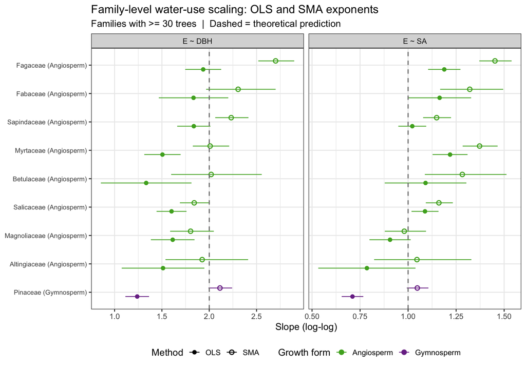

Forest plot of family-level OLS (filled circle, primary) and SMA (open circle, secondary) scaling exponents for E~DBH and E~SA. Colours indicate growth form; dashed lines mark theoretical predictions.

# 7 Intraspecific scaling

When enough individual trees are measured per species (minimum 10 here), within-species (intraspecific) scaling exponents can be estimated. Intraspecific slopes quantify developmental allometry within a species and can differ from interspecific slopes due to plastic responses, site effects, and ontogeny.

```r
intra_fits <- NULL
MIN_N_SP   <- 10

if ("pl_species" %in% names(dat) && !all(is.na(dat$pl_species))) {
  sp_ok <- names(which(
    table(dat$pl_species[!is.na(dat$pl_species)]) >= MIN_N_SP
  ))
  cat("Species with >=", MIN_N_SP, "trees:", length(sp_ok), "\n")

  if (length(sp_ok) >= 3) {
    sp_dat    <- dat |>
      filter(pl_species %in% sp_ok, !is.na(log_dbh),
             !is.na(log_sa), !is.na(log_e))
    sp_groups <- split(sp_dat, sp_dat$pl_species)

    intra_fits <- bind_rows(lapply(sp_groups, function(d) {
      fam <- if ("family" %in% names(d)) d$family[[1]] else NA_character_
      ols_d <- lm(log_e ~ log_dbh, data = d)
      sma_d <- tryCatch(sma(log_e ~ log_dbh, data = d, method = "SMA"),
                        error = function(e) NULL)
      ols_s <- lm(log_e ~ log_sa, data = d)
      sma_s <- tryCatch(sma(log_e ~ log_sa,  data = d, method = "SMA"),
                        error = function(e) NULL)
      tibble(
        pl_species  = d$pl_species[[1]],
        growth_form = d$growth_form[[1]],
        family      = fam,
        n           = nrow(d),
        ols_sl_d = as.numeric(coef(ols_d)[2]),
        ols_lo_d = tryCatch(as.numeric(confint(ols_d)[2,1]), error=function(e) NA_real_),
        ols_hi_d = tryCatch(as.numeric(confint(ols_d)[2,2]), error=function(e) NA_real_),
        sma_sl_d = if (is.null(sma_d)) NA_real_ else as.numeric(coef(sma_d)[2]),
        sma_lo_d = if (is.null(sma_d)) NA_real_ else as.numeric(sma_d$coef[[1]][2,2]),
        sma_hi_d = if (is.null(sma_d)) NA_real_ else as.numeric(sma_d$coef[[1]][2,3]),
        ols_sl_s = as.numeric(coef(ols_s)[2]),
        ols_lo_s = tryCatch(as.numeric(confint(ols_s)[2,1]), error=function(e) NA_real_),
        ols_hi_s = tryCatch(as.numeric(confint(ols_s)[2,2]), error=function(e) NA_real_),
        sma_sl_s = if (is.null(sma_s)) NA_real_ else as.numeric(coef(sma_s)[2]),
        sma_lo_s = if (is.null(sma_s)) NA_real_ else as.numeric(sma_s$coef[[1]][2,2]),
        sma_hi_s = if (is.null(sma_s)) NA_real_ else as.numeric(sma_s$coef[[1]][2,3])
      )
    }))
    cat("Species with valid fits:", nrow(intra_fits), "\n")

    # Summary by growth form
    intra_summ <- do.call(rbind, lapply(
      split(intra_fits, intra_fits$growth_form),
      function(g) data.frame(
        `Growth form`    = g$growth_form[1],
        `N spp`          = nrow(g),
        `Mean OLS(E~D)`  = round(mean(g$ols_sl_d, na.rm=TRUE), 3),
        `SD OLS(E~D)`    = round(sd(g$ols_sl_d,   na.rm=TRUE), 3),
        `Mean SMA(E~D)`  = round(mean(g$sma_sl_d, na.rm=TRUE), 3),
        `Mean OLS(E~SA)` = round(mean(g$ols_sl_s, na.rm=TRUE), 3),
        `SD OLS(E~SA)`   = round(sd(g$ols_sl_s,   na.rm=TRUE), 3),
        `Mean SMA(E~SA)` = round(mean(g$sma_sl_s, na.rm=TRUE), 3),
        check.names = FALSE, stringsAsFactors = FALSE
      )
    ))
    kable(intra_summ,
          caption = paste0(
            if (!USE_REAL_DATA) "\u26a0 DEMONSTRATION DATA \u2014 ",
            "Mean intraspecific scaling exponents by growth form. ",
            "OLS = Model I (primary); SMA = Model II. ",
            "Based on species with >= ", MIN_N_SP, " individual trees."
          ))
  } else {
    cat("Fewer than 3 species with >=", MIN_N_SP,
        "trees \u2014 intraspecific analysis skipped.\n")
  }
} else {
  cat("pl_species not available \u2014 intraspecific scaling requires species data.\n")
}
```

```
## Species with >= 10 trees: 47
## Species with valid fits: 47
```

Mean intraspecific scaling exponents by growth form. OLS = Model I (primary); SMA = Model II. Based on species with >= 10 individual trees.

|  | Growth form | N spp | Mean OLS(E~D) | SD OLS(E~D) | Mean SMA(E~D) | Mean OLS(E~SA) | SD OLS(E~SA) | Mean SMA(E~SA) |
| --- | --- | --- | --- | --- | --- | --- | --- | --- |
| Angiosperm | Angiosperm | 34 | 1.575 | 0.780 | 2.419 | 1.00 | 0.385 | 1.302 |
| Gymnosperm | Gymnosperm | 13 | 1.600 | 0.773 | 1.854 | 1.08 | 0.304 | 1.360 |

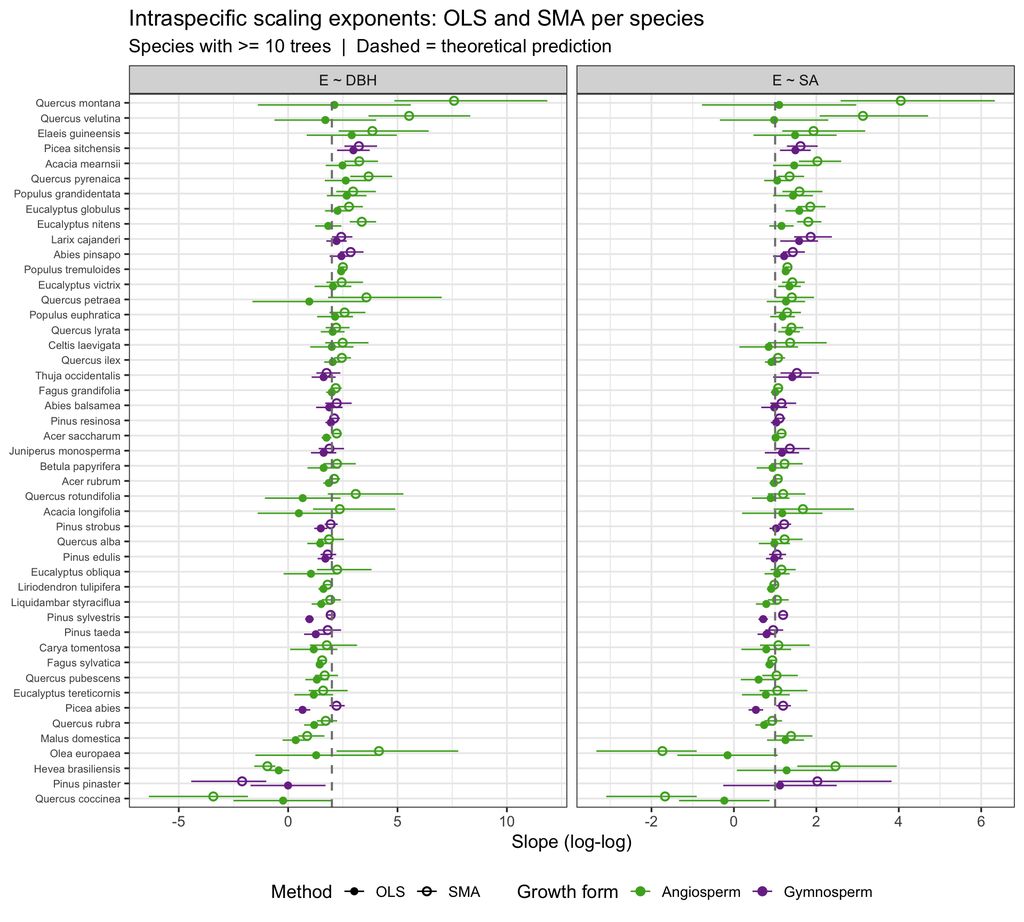

Forest plot of intraspecific OLS (filled, primary) and SMA (open, secondary) scaling exponents per species for E~DBH and E~SA. Coloured by growth form. Dashed lines mark theoretical predictions.

```r
if (!is.null(intra_fits) && nrow(intra_fits) >= 3) {
  intra_long <- bind_rows(
    intra_fits |>
      transmute(pl_species, growth_form, n, metric = "E ~ DBH", ref = 2.0,
                ols_est = ols_sl_d, ols_lo = ols_lo_d, ols_hi = ols_hi_d,
                sma_est = sma_sl_d, sma_lo = sma_lo_d, sma_hi = sma_hi_d),
    intra_fits |>
      transmute(pl_species, growth_form, n, metric = "E ~ SA",  ref = 1.0,
                ols_est = ols_sl_s, ols_lo = ols_lo_s, ols_hi = ols_hi_s,
                sma_est = sma_sl_s, sma_lo = sma_lo_s, sma_hi = sma_hi_s)
  )
  intra_forest <- bind_rows(
    intra_long |> mutate(method = "OLS", est = ols_est, lo = ols_lo, hi = ols_hi),
    intra_long |> mutate(method = "SMA", est = sma_est, lo = sma_lo, hi = sma_hi)
  ) |> filter(!is.na(est))

  ggplot(intra_forest,
         aes(y = reorder(pl_species, est), x = est, xmin = lo, xmax = hi,
             colour = growth_form, shape = method)) +
    geom_pointrange(size = 0.5, position = position_dodge(width = 0.55)) +
    geom_vline(data = distinct(intra_forest, metric, ref),
               aes(xintercept = ref), linetype = "dashed",
               colour = "grey50", linewidth = 0.7, inherit.aes = FALSE) +
    scale_colour_manual(values = c(Angiosperm = "#4dac26", Gymnosperm = "#7b3294"),
                        name = "Growth form") +
    scale_shape_manual(values = c(OLS = 16, SMA = 21), name = "Method") +
    facet_wrap(~ metric, scales = "free_x", ncol = 2) +
    labs(x = "Slope (log-log)", y = NULL,
         title = "Intraspecific scaling exponents: OLS and SMA per species",
         subtitle = paste0("Species with >= ", MIN_N_SP,
                           " trees  |  Dashed = theoretical prediction")) +
    theme(axis.text.y = element_text(size = 7.5), legend.position = "bottom")
}
```

```
## E ~ DBH: intraspecific mean OLS = 1.582 (SD = 0.770, n = 47 spp)  |  pooled = 1.507
## E ~ SA:  intraspecific mean OLS = 1.022 (SD = 0.363, n = 47 spp)  |  pooled = 0.926
```

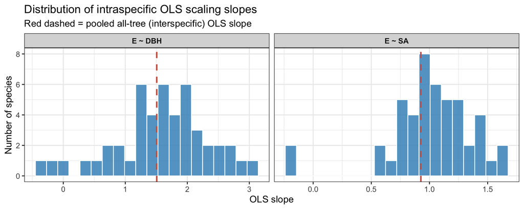

Distribution of intraspecific OLS slopes across species for E~DBH (left) and E~SA (right). Red dashed line = pooled all-tree (interspecific) OLS slope. Overlap or divergence from the pooled slope indicates whether within-species and between-species scaling share the same exponent.

```r
if (!is.null(intra_fits) && nrow(intra_fits) >= 3) {
  inter_d <- round(coef(fit_ols_dbh)["log_dbh"], 3)
  inter_s <- round(coef(fit_ols_sa)["log_sa"],   3)

  cat(sprintf(
    "E ~ DBH: intraspecific mean OLS = %.3f (SD = %.3f, n = %d spp)  |  pooled = %.3f\n",
    mean(intra_fits$ols_sl_d, na.rm = TRUE),
    sd(intra_fits$ols_sl_d,   na.rm = TRUE),
    sum(!is.na(intra_fits$ols_sl_d)),
    inter_d
  ))
  cat(sprintf(
    "E ~ SA:  intraspecific mean OLS = %.3f (SD = %.3f, n = %d spp)  |  pooled = %.3f\n",
    mean(intra_fits$ols_sl_s, na.rm = TRUE),
    sd(intra_fits$ols_sl_s,   na.rm = TRUE),
    sum(!is.na(intra_fits$ols_sl_s)),
    inter_s
  ))

  intra_slope_df <- rbind(
    data.frame(slope  = intra_fits$ols_sl_d[!is.na(intra_fits$ols_sl_d)],
               metric = "E ~ DBH", inter_slope = inter_d),
    data.frame(slope  = intra_fits$ols_sl_s[!is.na(intra_fits$ols_sl_s)],
               metric = "E ~ SA",  inter_slope = inter_s)
  )

  ggplot(intra_slope_df, aes(x = slope)) +
    geom_histogram(bins = 20, fill = "#4393c3", colour = "white", alpha = 0.85) +
    geom_vline(aes(xintercept = inter_slope), colour = "#d6604d",
               linetype = "dashed", linewidth = 1.0) +
    facet_wrap(~ metric, scales = "free_x", ncol = 2) +
    labs(x = "OLS slope", y = "Number of species",
         title = "Distribution of intraspecific OLS scaling slopes",
         subtitle = "Red dashed = pooled all-tree (interspecific) OLS slope") +
    theme(strip.text = element_text(face = "bold"))
}
```